# Features Best for Predicting Borrower APR

## by (Olamide Ige)

## Investigation Overview

In this investigation, I want to focus on the varables that is best for predicting Borrower APR, The main focus will be on BorrowerAPR, Loan amount, Prosper Score Amount, Term.

## Dataset Overview

This data set contains 113,937 loans with 81 variables on each loan, including loan amount, borrower rate (or interest rate), current loan status, borrower income, and many others.

## Distribution of Borrower Annual Percentage Rate

BorrowerAPR in the dataset takes on range of values, from about 6% at the lowest to about 43% at the highest value. The disribution of Borrower Annual Percentage Rate takes on a multimodal shape because it three or more peaks with the higest occuring around 36%

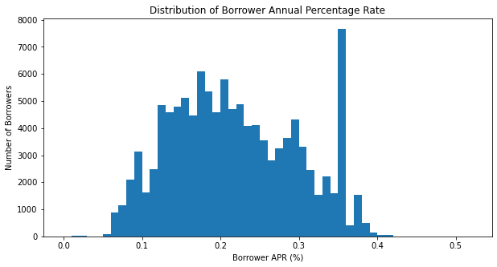

## Distribution of Loan Amount collected by Prosper Borrowers

Loan Original Amount in the dataset plotted on a logarithm scale takes on value from around 1k to around 30k. The distribution of Loan amount takes on a multimodal shape with the highest peak around $4k

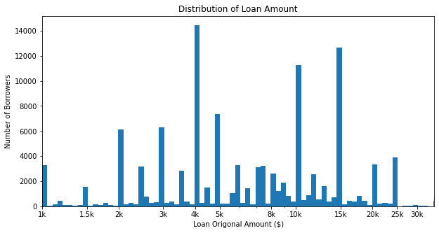

## Distribution of Prosper Rating

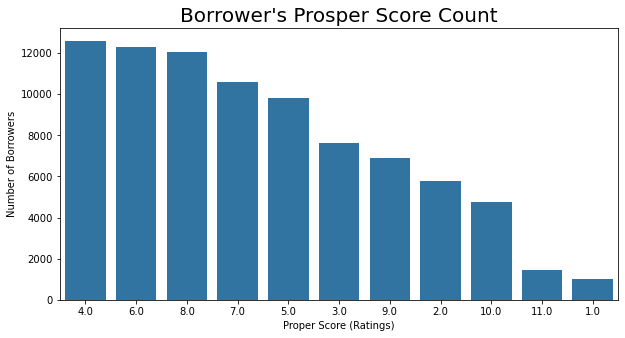

## Borrower APR vs Loan Amount

The plot depicts that a negative correlation relationship exist Loan amoount and Borrower APR. As loan amount increases, the borrower APR reduces and vice versa

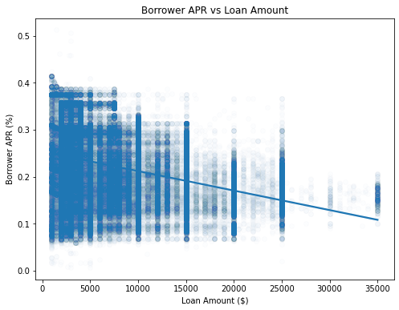

## Borrower APR and Prosper Score by Term

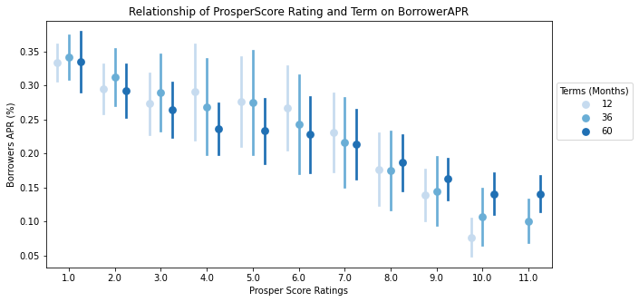